# Multivariate_Assignment

Julie Raiguel

February 8, 2018

## Code for Question 1

Here I load the package vegan because its functions are commonly used in ordination. I also load the data frame dune, which tells the abundance of species in 20 sites, and the data frame dune.env, which tells some environmental conditions at those sites.

```r
library(vegan)
source('https://raw.githubusercontent.com/dmcglinn/quant_methods/gh-pages/scripts/utility_functions.R')

data(dune)
data(dune.env)
?dune
```

```
## starting httpd help server ...
```

```
##  done
```

I look at the data to see if the row names line up between the abundance and explanatory matrices. The sites are labeled 1 through 20 and are listed in that order in both data frames. Then I run an NMDS analysis on the abundance data frame. This method is an Unconstrained approach because it does not use an explanatory matrix. Additionally, it does not use eigenvalues. It repeats random iterations to find the model with the lowest possible stress value.

```r
head(dune)
```

```
##   Achimill Agrostol Airaprae Alopgeni Anthodor Bellpere Bromhord Chenalbu
## 1        1        0        0        0        0        0        0        0
## 2        3        0        0        2        0        3        4        0
## 3        0        4        0        7        0        2        0        0
## 4        0        8        0        2        0        2        3        0
## 5        2        0        0        0        4        2        2        0
## 6        2        0        0        0        3        0        0        0
##   Cirsarve Comapalu Eleopalu Elymrepe Empenigr Hyporadi Juncarti Juncbufo
## 1        0        0        0        4        0        0        0        0
## 2        0        0        0        4        0        0        0        0
## 3        0        0        0        4        0        0        0        0
## 4        2        0        0        4        0        0        0        0
## 5        0        0        0        4        0        0        0        0
## 6        0        0        0        0        0        0        0        0
##   Lolipere Planlanc Poaprat Poatriv Ranuflam Rumeacet Sagiproc Salirepe
## 1        7        0       4       2        0        0        0        0
## 2        5        0       4       7        0        0        0        0
## 3        6        0       5       6        0        0        0        0
## 4        5        0       4       5        0        0        5        0
## 5        2        5       2       6        0        5        0        0
## 6        6        5       3       4        0        6        0        0
##   Scorautu Trifprat Trifrepe Vicilath Bracruta Callcusp
## 1        0        0        0        0        0        0
## 2        5        0        5        0        0        0
## 3        2        0        2        0        2        0
## 4        2        0        1        0        2        0
## 5        3        2        2        0        2        0
## 6        3        5        5        0        6        0
```

```r
head(dune.env)
```

```
##    A1 Moisture Management      Use Manure
## 1 2.8        1         SF Haypastu      4
## 2 3.5        1         BF Haypastu      2
## 3 4.3        2         SF Haypastu      4
## 4 4.2        2         SF Haypastu      4
## 5 6.3        1         HF Hayfield      2
## 6 4.3        1         HF Haypastu      2
```

```r
dune_mds = metaMDS(dune)
```

```
## *** Solution reached
```

I plot the NMDS model. The species names are written and the dots indicate the 20 sites. The color of the dots indicates their moisture value.

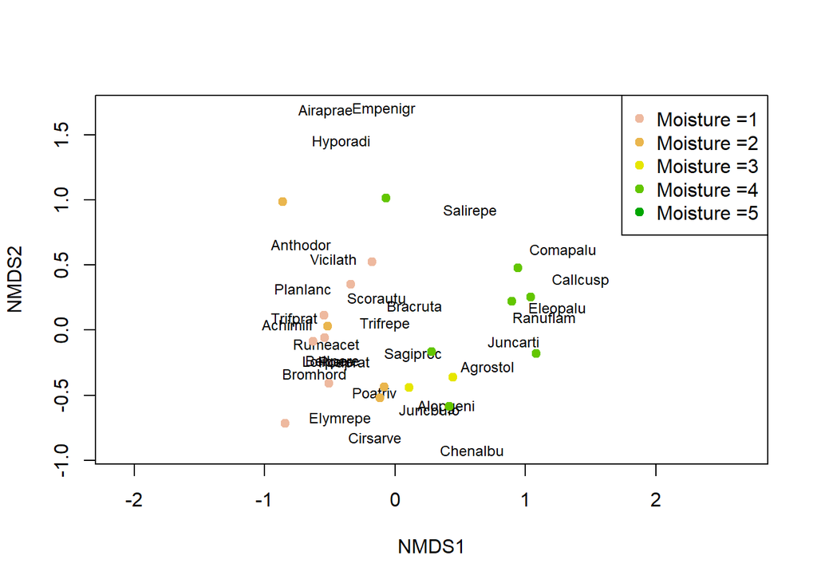

```r
plot(dune_mds, type='n')
 text(dune_mds, 'sp', cex=0.75)
 color_vect = rev(terrain.colors(6))[-1]
 points(dune_mds, 'sites', pch=19,
        col=color_vect[dune.env$Moisture])
 legend('topright', paste("Moisture =", 1:5, sep=''),
        col=color_vect, pch=19)
```

When the same plot is made with the manure rankings, there appears to be a vertical gradient, but it is not nearly as strong as the moisture one.

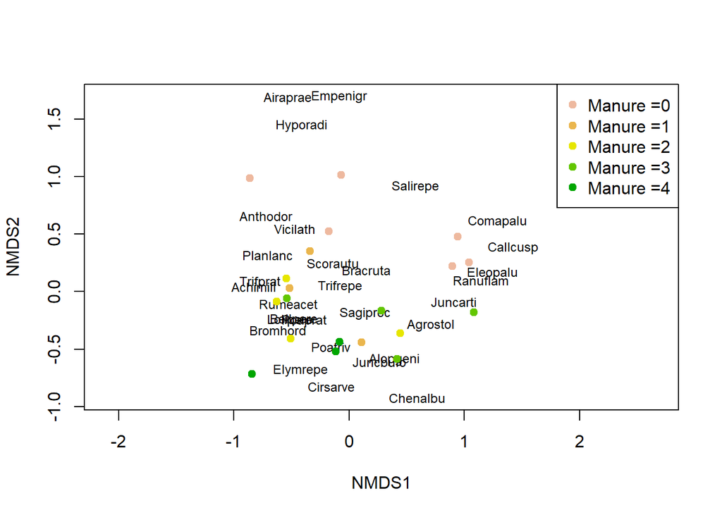

```r
plot(dune_mds, type='n')
 text(dune_mds, 'sp', cex=0.75)
 color_vect = rev(terrain.colors(6))[-1]
 points(dune_mds, 'sites', pch=19,
        col=color_vect[dune.env$Manure])
 legend('topright', paste("Manure =", 0:4, sep=''),
        col=color_vect, pch=19)
```

## Answers to Question 1

- Describe how you interpret the [moisture] graphic.
  - This graphic shows two axes of variation. The species are relatively randomly scattered across both the vertical and horizontal axes. I intepret this to mean that that many different species of dune vegetation have varying preferences for environmental conditions.
  - However, some are clumped together, like *Lolium perenne* (Lolpere) and *Poa pratensis* (Poaprat) towards the left and *Eleocharis palustris* (Eleopalu) and *Ranunculus flammula* (Ranuflam) towards the right. Each species in the pair likes similar conditions to the other since there are together in the model. The pairs themselves are far apart horizontally so they like very different conditions in the spectrum indicated by that axis but are closer together vertically, so their tolerated differences in that variable are less extreme.
  - Since the moisture of the sites is overlayed on the unconstrained plot, we can see a gradient of moisture moving horizontally based on the colors. Farther to the left, near the pink dots, are species that like drier sites (including *Lolium perenne* and *Poa pratensis*). Farther to the right, near the green dots, are the species that like wet sites (including *Eleocharis palustris* and *Ranunculus flammula*). The gradient of colors created by the site indicators indicates that moisture may be the primary axis of this model.
  - The secondary axis is unknown because no other explanatory variable is overlayed, and I do not know enough about these species to develop any hypotheses about what is very different about the sites preferred by *Empetrum nigrum* (Empenigr) and *Cirsium arvense* (Cirsarve), which appear to like the same moisture level.
- What is the goal of creating such a plot?
  - The goal of creating the plot in general is to see what species clump together and to form any hypotheses about what causes this in the model.
  - This particular plot includes the explanatory variable of moisture overlayed on top of the unconstrained model. The purpose of that is to test a hypothesis that moisture may be the primary axis in this model. This plot helps the researcher to decide whether moisture may explain variance in this dataset.
- Does this analysis suggest any interesting findings with respect to dune vegetation?
  - This analysis does not show a lot of clumping. Many of the dune species seem to have their own unique preferences of environmental conditions.
  - It also shows that moisture level is very important in determining which species will live where.
  - While dune habitats seem to be all the same to the casual observer, there is a great variety of species specialized to live in many different types of sites.

## Code and Answers for Question 2

I create a model using Canonical Correspondence Analysis (CCA). In this model, I include all available explantory variables in dune.env. At first, the Proportion and R-squared value looks awesome since the model explains 71% of the variance. However, the adjusted R-squared shows that much of that was randomly expected since so many variables were included. The explanatory variables actually only explain 23% of the variance.

```r
cca_dune = cca(dune ~ ., data=dune.env)
cca_dune
```

```
## Call: cca(formula = dune ~ A1 + Moisture + Management + Use +
## Manure, data = dune.env)
##
##               Inertia Proportion Rank
## Total          2.1153     1.0000
## Constrained    1.5032     0.7106   12
## Unconstrained  0.6121     0.2894    7
## Inertia is mean squared contingency coefficient
## Some constraints were aliased because they were collinear (redundant)
##
## Eigenvalues for constrained axes:
##   CCA1   CCA2   CCA3   CCA4   CCA5   CCA6   CCA7   CCA8   CCA9  CCA10
## 0.4671 0.3410 0.1761 0.1532 0.0953 0.0703 0.0589 0.0499 0.0318 0.0260
##  CCA11  CCA12
## 0.0228 0.0108
##
## Eigenvalues for unconstrained axes:
##     CA1     CA2     CA3     CA4     CA5     CA6     CA7
## 0.27237 0.10876 0.08975 0.06305 0.03489 0.02529 0.01798
```

```r
RsquareAdj(cca_dune)
```

```
## $r.squared
## [1] 0.7106267
##
## $adj.r.squared
## [1] 0.2368537
```

This first plot is a mess because all of the variables were treated as categorical except A1.

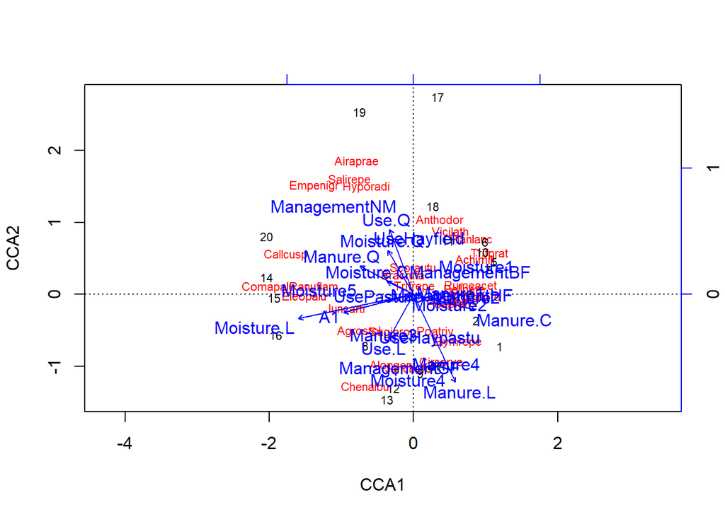

```r
plot(cca_dune)
```

```r
dune.env
```

```
##      A1 Moisture Management      Use Manure
## 1   2.8        1         SF Haypastu      4
## 2   3.5        1         BF Haypastu      2
## 3   4.3        2         SF Haypastu      4
## 4   4.2        2         SF Haypastu      4
## 5   6.3        1         HF Hayfield      2
## 6   4.3        1         HF Haypastu      2
## 7   2.8        1         HF  Pasture      3
## 8   4.2        5         HF  Pasture      3
## 9   3.7        4         HF Hayfield      1
## 10  3.3        2         BF Hayfield      1
## 11  3.5        1         BF  Pasture      1
## 12  5.8        4         SF Haypastu      2
## 13  6.0        5         SF Haypastu      3
## 14  9.3        5         NM  Pasture      0
## 15 11.5        5         NM Haypastu      0
## 16  5.7        5         SF  Pasture      3
## 17  4.0        2         NM Hayfield      0
## 18  4.6        1         NM Hayfield      0
## 19  3.7        5         NM Hayfield      0
## 20  3.5        5         NM Hayfield      0
```

```r
class(dune.env$Moisture)
```

```
## [1] "ordered" "factor"
```

```r
dune.env$Moisture = as.integer(dune.env$Moisture)

class(dune.env$A1)
```

```
## [1] "numeric"
```

```r
class(dune.env$Manure)
```

```
## [1] "ordered" "factor"
```

```r
dune.env$Manure = as.integer(dune.env$Manure)
```

In this new plot, moisture and manure have their own axes and it is much less cluttered. Moisture appears to be the strongest variable along the horizontal axis and manure the strongest along the vertical axis.

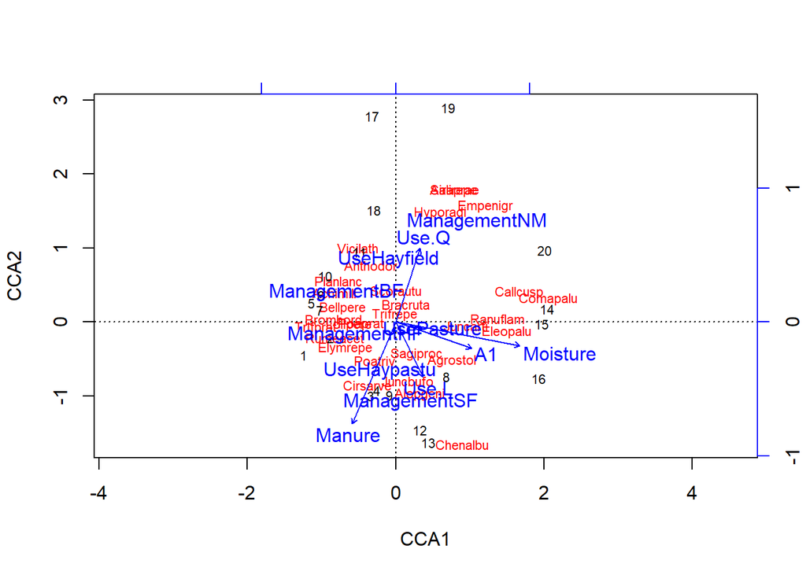

```r
cca_dune = cca(dune ~ ., data=dune.env)
plot(cca_dune)
```

```r
cca_dune
```

```
## Call: cca(formula = dune ~ A1 + Moisture + Management + Use +
## Manure, data = dune.env)
##
##               Inertia Proportion Rank
## Total          2.1153     1.0000
## Constrained    1.2128     0.5733    8
## Unconstrained  0.9025     0.4267   11
## Inertia is mean squared contingency coefficient
##
## Eigenvalues for constrained axes:
##   CCA1   CCA2   CCA3   CCA4   CCA5   CCA6   CCA7   CCA8
## 0.4601 0.2954 0.1579 0.1337 0.0659 0.0406 0.0341 0.0251
##
## Eigenvalues for unconstrained axes:
##     CA1     CA2     CA3     CA4     CA5     CA6     CA7     CA8     CA9
## 0.29542 0.13548 0.10574 0.10085 0.07773 0.05656 0.05106 0.03564 0.02477
##    CA10    CA11
## 0.01288 0.00635
```

```r
RsquareAdj(cca_dune)
```

```
## $r.squared
## [1] 0.5733491
##
## $adj.r.squared
## [1] 0.2788818
```

Moisture is found to be the most significant of the explanatory variables when an anova is run. This is unsurprising considering it is most correlated with the primary axis (CCA1) and that axis accounts for 38% (0.4601/1.2128) of the variance explained by the constrained axes.

```r
anova(cca_dune, by='margin', permutations = 100)
```

```
## Permutation test for cca under reduced model
## Marginal effects of terms
## Permutation: free
## Number of permutations: 100
##
## Model: cca(formula = dune ~ A1 + Moisture + Management + Use + Manure, data = dune.env)
##            Df ChiSquare      F Pr(>F)
## A1          1   0.10858 1.3235 0.2475
## Moisture    1   0.17380 2.1183 0.0396 *
## Management  3   0.31036 1.2610 0.1287
## Use         2   0.13323 0.8120 0.6733
## Manure      1   0.09070 1.1055 0.3267
## Residual   11   0.90248
## ---
## Signif. codes:  0 '***' 0.001 '**' 0.01 '*' 0.05 '.' 0.1 ' ' 1
```

Moisture is tested as the only constrained axis. The adjusted R-squared decreased to 15%, but it is much closer to the R-squared value, so little of the explanation is randomly expected. This plot is most similar to the NMDS plot. For example, species like *Eleocharus palustris* and *Ranunculus flammula* are still together on the right where sites with more moisture are located. However, the distribution of species along the vertical axis is different.

```r
cca_dune_moisture = cca(dune ~ Moisture, data=dune.env)
cca_dune_moisture
```

```
## Call: cca(formula = dune ~ Moisture, data = dune.env)
##
##               Inertia Proportion Rank
## Total          2.1153     1.0000
## Constrained    0.4108     0.1942    1
## Unconstrained  1.7045     0.8058   18
## Inertia is mean squared contingency coefficient
##
## Eigenvalues for constrained axes:
##   CCA1
## 0.4108
##
## Eigenvalues for unconstrained axes:
##    CA1    CA2    CA3    CA4    CA5    CA6    CA7    CA8
## 0.4180 0.3148 0.1835 0.1510 0.1082 0.0925 0.0878 0.0737
## (Showed only 8 of all 18 unconstrained eigenvalues)
```

```r
RsquareAdj(cca_dune_moisture)
```

```
## $r.squared
## [1] 0.1942128
##
## $adj.r.squared
## [1] 0.1511652
```

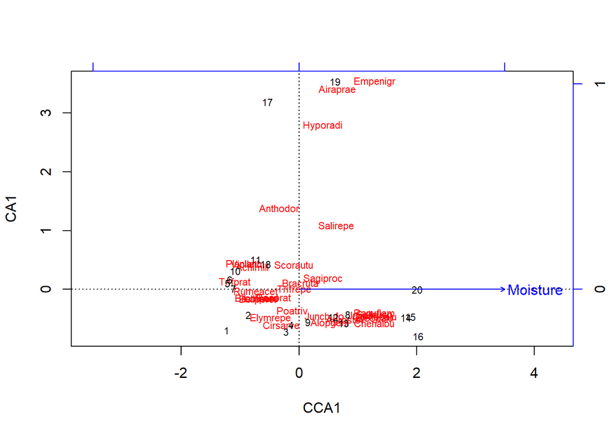

```r
plot(cca_dune_moisture)
```

```r
cca_dune_Management = cca(dune ~ Management, data = dune.env)
cca_dune_Management
```

```
## Call: cca(formula = dune ~ Management, data = dune.env)
##
##               Inertia Proportion Rank
## Total          2.1153     1.0000
## Constrained    0.6038     0.2855    3
## Unconstrained  1.5114     0.7145   16
## Inertia is mean squared contingency coefficient
##
## Eigenvalues for constrained axes:
##   CCA1   CCA2   CCA3
## 0.3186 0.1825 0.1027
##
## Eigenvalues for unconstrained axes:
##    CA1    CA2    CA3    CA4    CA5    CA6    CA7    CA8    CA9   CA10
## 0.4474 0.2030 0.1630 0.1346 0.1294 0.0949 0.0790 0.0653 0.0500 0.0432
##   CA11   CA12   CA13   CA14   CA15   CA16
## 0.0387 0.0239 0.0177 0.0092 0.0080 0.0042
```

```r
RsquareAdj(cca_dune_Management)
```

```
## $r.squared
## [1] 0.285467
##
## $adj.r.squared
## [1] 0.1560426
```

This plot is a little different. Instead looking at a gradient across the plot in a certain direction, species clumped near each category of Management seem to prefer that managment type. For example, *Bromus hordaceus* (Bromhord) appears to prefer sites where hobby farming occurs.

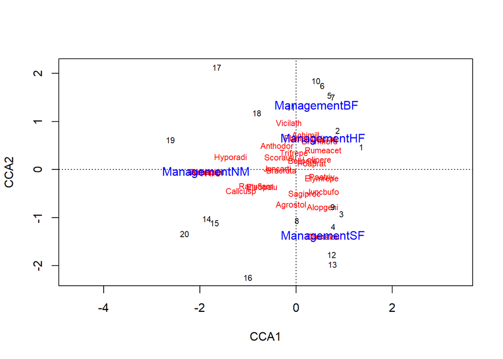

```r
plot(cca_dune_Management)
```

```r
cca_dune_A1 =  cca(dune ~ A1, data=dune.env)
cca_dune_A1
```

```
## Call: cca(formula = dune ~ A1, data = dune.env)
##
##               Inertia Proportion Rank
## Total          2.1153     1.0000
## Constrained    0.2248     0.1063    1
## Unconstrained  1.8905     0.8937   18
## Inertia is mean squared contingency coefficient
##
## Eigenvalues for constrained axes:
##    CCA1
## 0.22476
##
## Eigenvalues for unconstrained axes:
##    CA1    CA2    CA3    CA4    CA5    CA6    CA7    CA8
## 0.4073 0.3938 0.2519 0.1662 0.1314 0.0975 0.0898 0.0747
## (Showed only 8 of all 18 unconstrained eigenvalues)
```

```r
RsquareAdj(cca_dune_A1)
```

```
## $r.squared
## [1] 0.1062564
##
## $adj.r.squared
## [1] 0.05854195
```

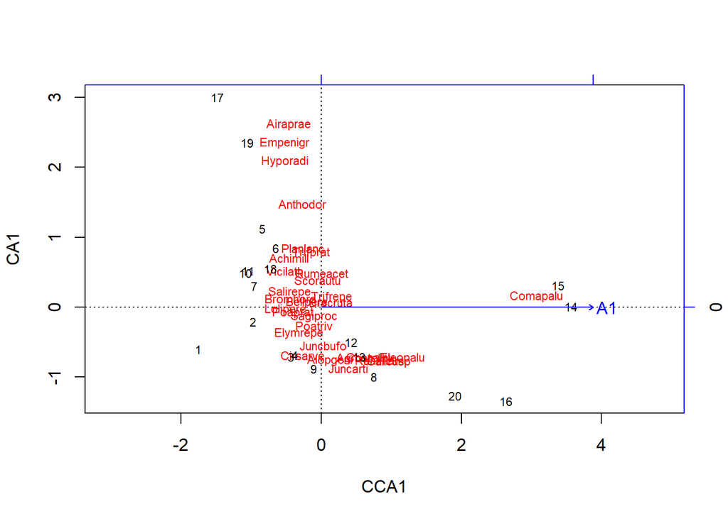

```r
plot(cca_dune_A1)
```

A model using just manure as a constrained axis shows a slightly higher adjusted R-squared than for A1. This makes sense considering the vertical component of the manure axis was longer than the horizontal axis of the A1 component in the original model.

```r
cca_dune_manure = cca(dune ~ Manure, data=dune.env)
cca_dune_manure
```

```
## Call: cca(formula = dune ~ Manure, data = dune.env)
##
##               Inertia Proportion Rank
## Total          2.1153     1.0000
## Constrained    0.2388     0.1129    1
## Unconstrained  1.8765     0.8871   18
## Inertia is mean squared contingency coefficient
##
## Eigenvalues for constrained axes:
##    CCA1
## 0.23876
##
## Eigenvalues for unconstrained axes:
##    CA1    CA2    CA3    CA4    CA5    CA6    CA7    CA8
## 0.5331 0.2852 0.2053 0.1758 0.1406 0.1022 0.0907 0.0803
## (Showed only 8 of all 18 unconstrained eigenvalues)
```

```r
RsquareAdj(cca_dune_manure)
```

```
## $r.squared
## [1] 0.112876
##
## $adj.r.squared
## [1] 0.06593447
```

When compared to the CCA plot that included all of the variables, this plot is turned about 90 degrees. For example, *Salix repens* (Salirepe) was at the top of the plot before and is now at the left. This is because manure was a large indicator of the vertical axis and it is now along the horizontal axis. In both cases, *Salix repens* was shown to like low levels of manure.

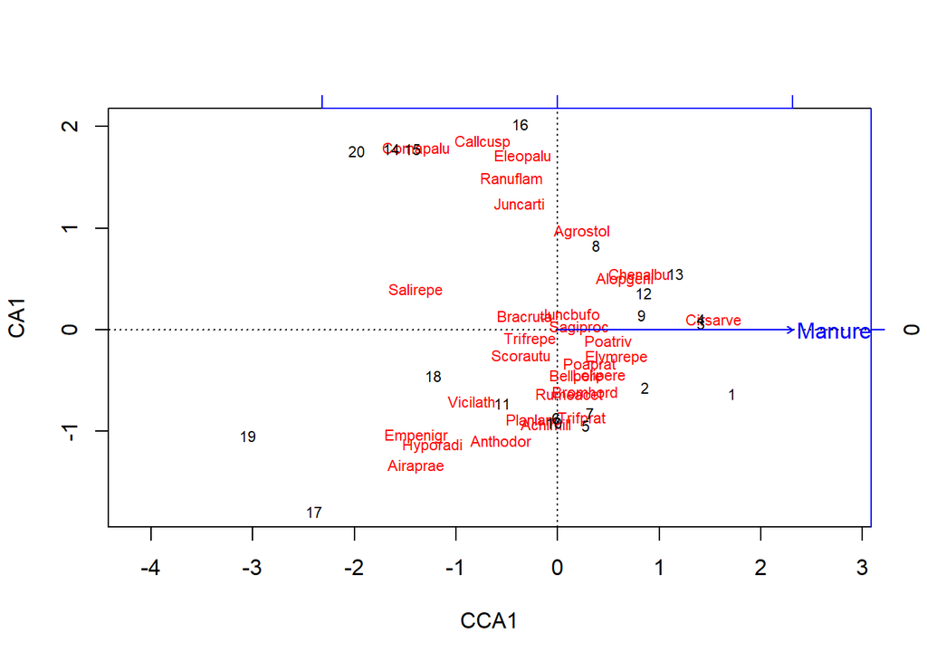

```r
plot(cca_dune_manure)
```

```r
cca_dune_Use = cca(dune ~ Use, data = dune.env)
cca_dune_Use
```

```
## Call: cca(formula = dune ~ Use, data = dune.env)
##
##               Inertia Proportion Rank
## Total          2.1153     1.0000
## Constrained    0.2507     0.1185    2
## Unconstrained  1.8645     0.8815   17
## Inertia is mean squared contingency coefficient
##
## Eigenvalues for constrained axes:
##    CCA1    CCA2
## 0.15249 0.09825
##
## Eigenvalues for unconstrained axes:
##    CA1    CA2    CA3    CA4    CA5    CA6    CA7    CA8
## 0.4929 0.3104 0.2322 0.1755 0.1420 0.1030 0.0782 0.0758
## (Showed only 8 of all 17 unconstrained eigenvalues)
```

```r
RsquareAdj(cca_dune_Use)
```

```
## $r.squared
## [1] 0.1185381
##
## $adj.r.squared
## [1] 0.01801519
```

To confirm understanding of the above analysis, a model with Management and moisture as constrained axes and a model with manure added to those were compared.

```r
cca_dune_Manag_Moist = cca(dune ~ Management + Moisture, data = dune.env)
cca_dune_Manag_Moist
```

```
## Call: cca(formula = dune ~ Management + Moisture, data = dune.env)
##
##               Inertia Proportion Rank
## Total          2.1153     1.0000
## Constrained    0.8564     0.4049    4
## Unconstrained  1.2588     0.5951   15
## Inertia is mean squared contingency coefficient
##
## Eigenvalues for constrained axes:
##   CCA1   CCA2   CCA3   CCA4
## 0.4355 0.2722 0.1030 0.0457
##
## Eigenvalues for unconstrained axes:
##    CA1    CA2    CA3    CA4    CA5    CA6    CA7    CA8    CA9   CA10
## 0.3709 0.1631 0.1379 0.1297 0.0956 0.0791 0.0656 0.0551 0.0455 0.0392
##   CA11   CA12   CA13   CA14   CA15
## 0.0271 0.0209 0.0170 0.0080 0.0042
```

```r
RsquareAdj(cca_dune_Manag_Moist)
```

```
## $r.squared
## [1] 0.4048847
##
## $adj.r.squared
## [1] 0.2513435
```

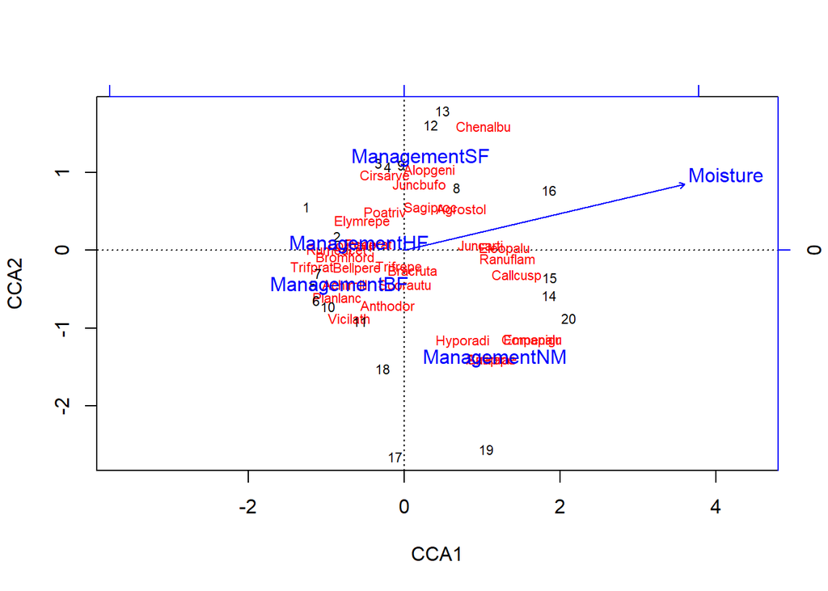

```r
plot(cca_dune_Manag_Moist)
```

```r
cca_dune_ManagMoist_Manure = cca(dune ~ Management + Moisture + Manure, data = dune.env)
cca_dune_ManagMoist_Manure
```

```
## Call: cca(formula = dune ~ Management + Moisture + Manure, data =
## dune.env)
##
##               Inertia Proportion Rank
## Total          2.1153     1.0000
## Constrained    0.9292     0.4393    5
## Unconstrained  1.1861     0.5607   14
## Inertia is mean squared contingency coefficient
##
## Eigenvalues for constrained axes:
##   CCA1   CCA2   CCA3   CCA4   CCA5
## 0.4357 0.2722 0.1288 0.0473 0.0453
##
## Eigenvalues for unconstrained axes:
##    CA1    CA2    CA3    CA4    CA5    CA6    CA7    CA8    CA9   CA10
## 0.3659 0.1631 0.1330 0.1058 0.0952 0.0786 0.0656 0.0507 0.0400 0.0314
##   CA11   CA12   CA13   CA14
## 0.0259 0.0179 0.0084 0.0047
```

```r
RsquareAdj(cca_dune_ManagMoist_Manure)
```

```
## $r.squared
## [1] 0.4392625
##
## $adj.r.squared
## [1] 0.2487171
```

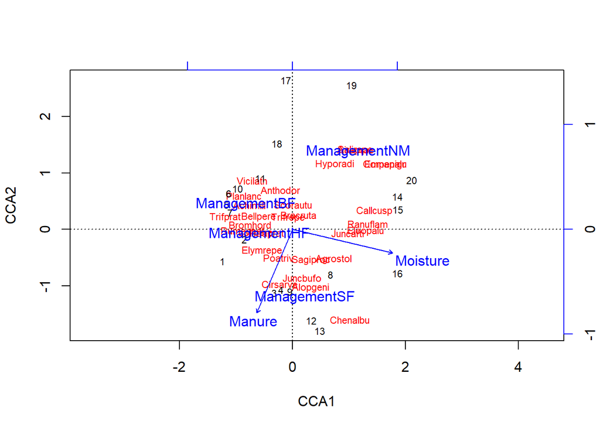

```r
plot(cca_dune_ManagMoist_Manure)
```

In this comparison, the R-squared value went up very little, most likely just because of the additional variable. The adjusted R-squared value decreased very little, also due to the added variable. Also, the location of the species with respect to each other and moisture and management in the plots changed very little. This reaffirms that manure is not very significant to this model.